# Gastos de Parlamentares em 2016

# Introdução

Os dados coletados abaixo foram coletados do site de transparência da câmara dos deputados. Esses dados contém todos os gastos de nossos deputados em 2016 de Janeiro a Maio, usando a sua cota para exercício da atividade parlamentar

## Tratando dos Dados

```r
ler_gastos <- function(arquivo = "../datasets/gastos.csv") {
  #' Lê um csv criado a partir dos dados de gastos dos deputados da
  #' Câmara e seta os tipos de colunas mais convenientemente.
  require("readr")
  require("dplyr", warn.conflicts = FALSE)

  gastos = read_csv(arquivo, col_types = list(datEmissao = col_datetime()))
  gastos = gastos %>%
    mutate_each(funs(as.factor), sgPartido, sgUF, txNomeParlamentar, indTipoDocumento, numMes)

  levels(gastos$numMes) =
    list("Janeiro"="1", "Fevereiro"="2", "Março"="3", "Abril"="4", "Maio"="5", "Junho"="6", "Julho"="7")

  return(gastos)
}

ler_cotas <- function(arquivo = "../datasets/cota.csv") {

  cota = read.csv(arquivo, sep = ";", dec = ",")
  return(cota)
}
```

## Carregando os Dados

```r
parlamentares = ler_gastos()

data = parlamentares %>%
  filter(!is.na(sgPartido),
         sgPartido != "S.PART.",
         numMes != "Junho", numMes != "Julho") %>%
  group_by(parlamentar = txNomeParlamentar, estado = sgUF, partido = sgPartido, mes = numMes) %>%
  summarise(gastos = sum(vlrDocumento)) %>%
  inner_join(ler_cotas(), by = c("estado" = "estado"))
```

## Questões

1. Qual é a distribuição dos gastos por partido, levando em consideração o tamanho da sua bancada?
- Como estamos interessados em analisar os gastos dos nossos parlamentares, levando em consideração o número de deputados em cada partido, então vamos então analizar a tabela abaixo:

| Partido | Bancada | Gastos | Cota |
| --- | --- | --- | --- |
| DEM | 29 | 4486542.4 | 5508667.3 |
| PCdoB | 12 | 2110642.2 | 2321678.7 |
| PDT | 22 | 3469449.9 | 4088870.0 |
| PEN | 3 | 438996.3 | 477332.6 |
| PHS | 7 | 1123048.6 | 1381909.4 |
| PMB | 2 | 163828.5 | 258485.2 |
| PMDB | 78 | 10839586.7 | 14198655.5 |
| PP | 52 | 7639833.0 | 9743758.8 |
| PPS | 10 | 1406615.7 | 1804096.3 |
| PR | 43 | 6761588.7 | 7915038.5 |
| PRB | 22 | 4033603.1 | 4315279.8 |
| PROS | 6 | 846956.2 | 992010.3 |
| PSB | 34 | 4832109.0 | 6405422.5 |
| PSC | 11 | 1352958.6 | 1855686.9 |
| PSD | 40 | 6019656.9 | 6924983.6 |
| PSDB | 55 | 7835495.5 | 9865624.1 |
| PSL | 2 | 282270.8 | 374822.8 |
| PSOL | 6 | 779843.0 | 1117972.1 |
| PT | 67 | 9563719.4 | 11597762.9 |
| PTB | 20 | 3245365.0 | 3841784.8 |
| PTdoB | 3 | 469398.6 | 567647.4 |
| PTN | 13 | 2447632.0 | 2503659.7 |
| PV | 7 | 1061713.6 | 1231813.9 |
| REDE | 4 | 548532.4 | 756338.5 |
| SD | 14 | 2188396.9 | 2665758.9 |

- Descrição dos Dados:
  - **Partido**: É um partido político que possui representação na câmara dos deputados;
  - **Bancada**: O número de deputados que o partido possui;
  - **Gastos** : A soma de todos os gastos de todos os deputados daquele partido;
  - **Cota** : A soma da cota parlamentar de todos os deputados daquele partido;
- Agora vamos analizar nossos dados graficamente:

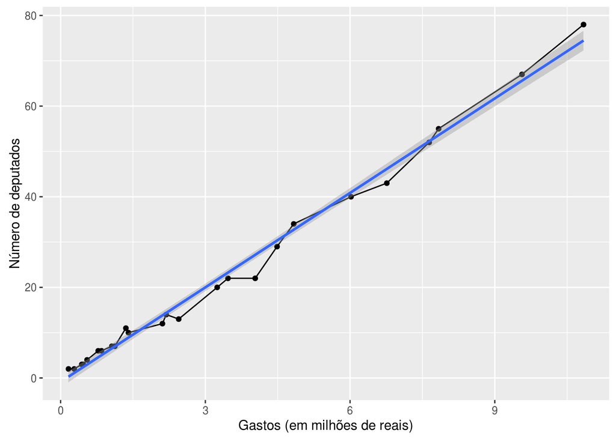

- Assim, podemos dizer que os gatos dos partidos aumentem de acordo com o tamanho da sua bancada, conforme a reta de regressão azul no gráfico;
- Podemos agora fazer a seguinte pergunta, existe algum partido que gasta mais que a sua cota?

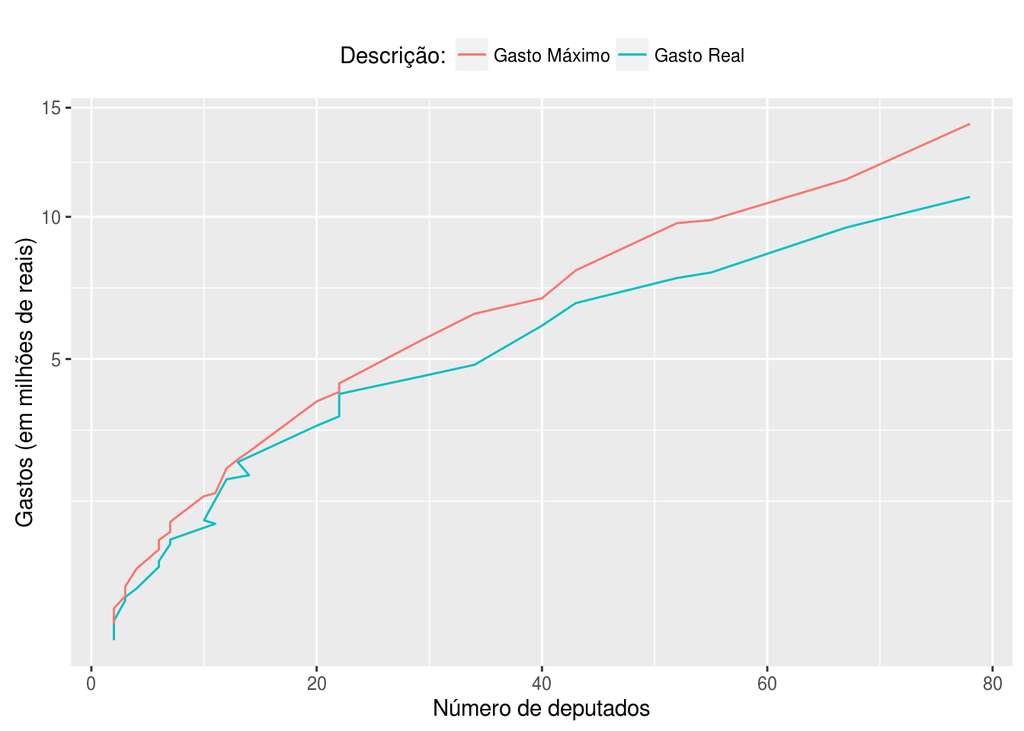

- Para esta nossa nova apesar do elevadíssimo gasto parlamentar nenhum partido gasta mais que o valor a sua cota;
2. Qual os gastos mais comuns por deputado?

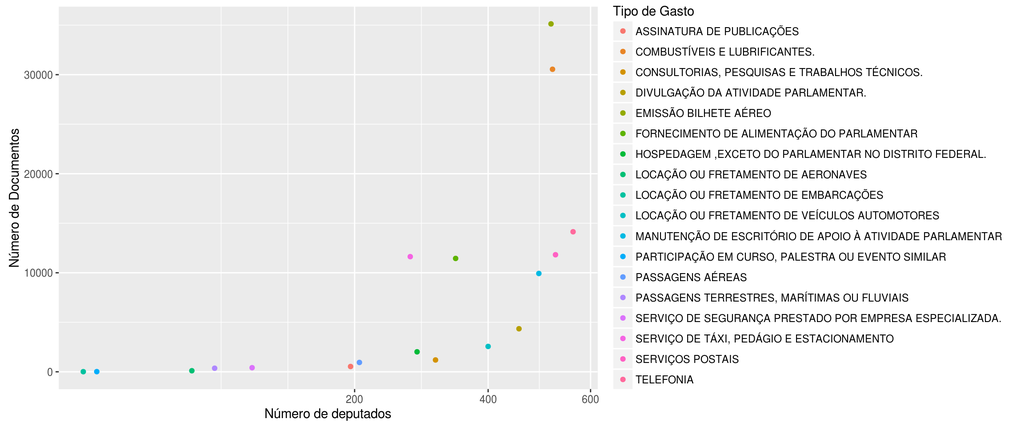

- Com a ajuda da gráfico acima podemos identificar que os três tipos de gastos mais comuns são entre os deputados são:
  - Emissão de Bilhete Aéreo,
  - Combustíveis e Lubrificantes e
  - Telefonia